# Esercitazione N.6

Author

Econometria

# Regressione con dati panel

Un panel contiene osservazioni su più unità (individui, stati, imprese) in cui ogni entità è osservata in due o più istanti temporali diversi:

Ad Esempio:

- Dati su 50 stati USA, ognuno è osservato per 3 anni, per un totale di 150 osservazioni.
- Dati su 1000 individuali, in quattro mesi diversi, per 4000 osservazioni in totale.

Con i dati panel possiamo controllare per fattori che:

- Variano tra le unità ma non nel tempo (ad esempio variabili inosservate che variano da stato a stato, ma che non cambiano nel tempo)
- Variabili che variano nel tempo, ma che non variano tra le unità
- Potrebbero causare distorsione da variabili omesse
- Sono inosservati o non misurati, e perciò non possono essere inclusi in una regressione multipla

**Idea chiave:** Se una variabile omessa non varia nel tempo, allora qualsiasi variazione in $Y$ nel tempo non può essere causata dalla variabile omessa.

### Pacchetti necessari:

```r
library(tidyverse)
library(knitr)
library(kableExtra)
library(modelsummary)
library(fixest)
library(wooldridge)
```

## Crimine e disoccupazione

Carichiamo il dataset `crime2` su 46 città osservate nel 1982 e 1987:

- $crmrte$: è il tasso di crimine per 1,000 abitanti cioè (crimini/popolazione) *1000
- $unem$: tasso di disoccupazione

```r
data("crime2", package = "wooldridge")
head(crime2)
```

```
     pop crimes unem officers pcinc west nrtheast south year  area d87   popden
1 229528  17136  8.2      326  8532    1        0     0   82  44.6   0 5146.368
2 246815  17306  3.7      321 12155    1        0     0   87  44.6   1 5533.969
3 814054  75654  8.1     1621  7551    1        0     0   82 375.0   0 2170.811
4 933177  83960  5.4     1803 11363    1        0     0   87 375.0   1 2488.472
5 374974  31352  9.0      633  8343    1        0     0   82  49.8   0 7529.599
6 406297  31364  5.9      685 11729    1        0     0   87  49.8   1 8158.574
    crmrte   offarea   lawexpc    polpc     lpop   loffic   lpcinc llawexpc
1 74.65756  7.309417  850.8599 1.420306 12.34378 5.786897 9.051579 6.746247
2 70.11729  7.197309 2262.4399 1.300569 12.41639 5.771441 9.405496 7.724199
3 92.93487  4.322667  875.0800 1.991268 13.60978 7.390799 8.929436 6.774315
4 89.97221  4.808000 1069.6400 1.932109 13.74635 7.497207 9.338118 6.975078
5 83.61113 12.710844 1121.8999 1.688117 12.83461 6.450470 9.029179 7.022779
6 77.19476 13.755020 1545.6000 1.685959 12.91484 6.529419 9.369820 7.343167
   lpopden   lcrimes    larea  lcrmrte     clcrimes      clpop    clcrmrte
1 8.546046  9.748937 3.797734 4.312912           NA         NA          NA
2 8.618661  9.758808 3.797734 4.250169 0.0098714828 0.07261372 -0.06274271
3 7.682856 11.233926 5.926926 4.531899           NA         NA          NA
4 7.819424 11.338096 5.926926 4.499501 0.1041698456 0.13656807 -0.03239822
5 8.926597 10.353033 3.908015 4.426177           NA         NA          NA
6 9.006824 10.353416 3.908015 4.346332 0.0003833771 0.08022785 -0.07984495
     lpolpc      clpolpc  cllawexp cunem   clpopden lcrmrt_1   ccrmrte
1 0.3508723           NA        NA    NA         NA       NA        NA
2 0.2628021 -0.088070214 0.9779520  -4.5 0.07261467 4.312912 -4.540268
3 0.6887718           NA        NA    NA         NA       NA        NA
4 0.6586123 -0.030159533 0.2007623  -2.7 0.13656807 4.531899 -2.962654
5 0.5236138           NA        NA    NA         NA       NA        NA
6 0.5223344 -0.001279354 0.3203883  -3.1 0.08022785 4.426177 -6.416374
```

Regressione del tasso di criminalità sul tasso di disoccupazione (1982 e 1987)

```r
regcrimcs <- feols(crmrte ~ unem, data = crime2, vcov = "hetero")
regcrimcs
```

```
OLS estimation, Dep. Var.: crmrte
Observations: 92
Standard-errors: Heteroskedasticity-robust
              Estimate Std. Error   t value  Pr(>|t|)
(Intercept) 103.243399   8.641502 11.947390 < 2.2e-16 ***
unem         -0.307664   0.910013 -0.338087   0.73608
---
Signif. codes:  0 '***' 0.001 '**' 0.01 '*' 0.05 '.' 0.1 ' ' 1
RMSE: 29.7   Adj. R2: -0.009888
```

Un aumento di un punto percentuale del tasso di disoccupazione è associato, in media, a una riduzione di 0.307 crimini per 1,000 abitanti.

### Dummy con l’anno

Regressione del tasso di criminalità (1982 e 1987) con variabile dummy relativa all’anno 1987 ($d87$ uguale ad uno se 1987 = 1)

```r
regcrimcs2 <- feols(crmrte ~ unem + d87, data = crime2, vcov = "hetero")
regcrimcs2
```

```
OLS estimation, Dep. Var.: crmrte
Observations: 92
Standard-errors: Heteroskedasticity-robust
             Estimate Std. Error  t value   Pr(>|t|)
(Intercept) 93.420250  10.457957 8.932935 5.1717e-14 ***
unem         0.426547   0.993554 0.429315 6.6873e-01
d87          7.940416   7.106315 1.117375 2.6684e-01
---
Signif. codes:  0 '***' 0.001 '**' 0.01 '*' 0.05 '.' 0.1 ' ' 1
RMSE: 29.5   Adj. R2: -0.009986
```

Questo è equivalente a stimare:

```r
regcrimcs_fe <- feols(crmrte ~ unem | year, data = crime2, vcov = "hetero")
regcrimcs_fe
```

```
OLS estimation, Dep. Var.: crmrte
Observations: 92
Fixed-effects: year: 2
Standard-errors: Heteroskedasticity-robust
     Estimate Std. Error  t value Pr(>|t|)
unem 0.426547   0.993554 0.429315  0.66873
---
Signif. codes:  0 '***' 0.001 '**' 0.01 '*' 0.05 '.' 0.1 ' ' 1
RMSE: 29.5     Adj. R2: -0.009986
             Within R2:  0.001446
```

### Deviazione dalle medie dell’anno (trasformazione within):

Stimiamo OLS usando dati “in deviazione dalle medie dell’anno”

```r
# Calcola media per gruppo (year)
crime2_dev <- crime2 %>%
  group_by(year) %>%
  mutate(crmrte_bar = mean(crmrte),  # media crmrte per anno
         unem_bar = mean(unem)) %>%   # media unem per anno
  ungroup() %>%
  mutate(Wcrmrte = crmrte - crmrte_bar,  # deviazione crmrte
         Wunem = unem - unem_bar)        # deviazione unem

# Stima modello sulle deviazioni
mod_crime_within <- feols(Wcrmrte ~ Wunem -1, data = crime2_dev, vcov = "hetero")
mod_crime_within
```

```
OLS estimation, Dep. Var.: Wcrmrte
Observations: 92
Standard-errors: Heteroskedasticity-robust
      Estimate Std. Error  t value Pr(>|t|)
Wunem 0.426547   0.982575 0.434112  0.66523
---
Signif. codes:  0 '***' 0.001 '**' 0.01 '*' 0.05 '.' 0.1 ' ' 1
RMSE: 29.5   Adj. R2: -0.009527
```

La regressione sulle variabili centrate ha già eliminato la media. Non c’è nulla da spiegare con l’intercetta.

Otteniamo lo stesso coefficiente 0.42.

### First difference

Quando $T = 2$, calcolare la differenza prima ed **includere l’intercetta** fornisce esattamente la stessa regressione di includere effetti individuali e temporali (vedete pagina 283, Stock e Watson).

- $ccrmrte$: variazione in crmrte (first difference già presente in `crime2`)
- $cunem$: variazione in unemployment rate (first difference già presente in `crime2`)

```r
regcrimcs_fd <- feols(ccrmrte ~ cunem, data = crime2, vcov = "hetero")
regcrimcs_fd
```

```
OLS estimation, Dep. Var.: ccrmrte
Observations: 46
Standard-errors: Heteroskedasticity-robust
            Estimate Std. Error t value  Pr(>|t|)
(Intercept)  15.4022   5.178907 2.97403 0.0047563 **
cunem         2.2180   0.815506 2.71978 0.0093165 **
---
Signif. codes:  0 '***' 0.001 '**' 0.01 '*' 0.05 '.' 0.1 ' ' 1
RMSE: 19.6   Adj. R2: 0.106852
```

Questo è coerente con molte teorie economiche e criminologiche:

- più disoccupazione potrebbe comportare più individui in difficoltà economica e quindi più incentivi a commettere reati
- meno opportunità lavorative potrebbe comportare più marginalizzazione sociale

## Panel Wage (wagepan)

Unique

Missing Pct.

Mean

SD

Min

Median

Max

Histogram

nr

545

0

5262.1

3496.1

13.0

4569.0

12548.0

[figure not shown]

year

8

0

1983.5

2.3

1980.0

1983.5

1987.0

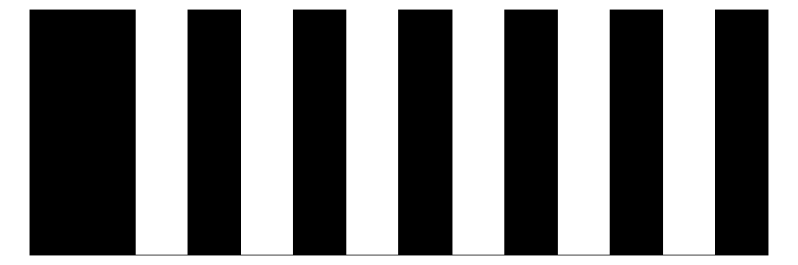

agric

2

0

0.0

0.2

0.0

0.0

1.0

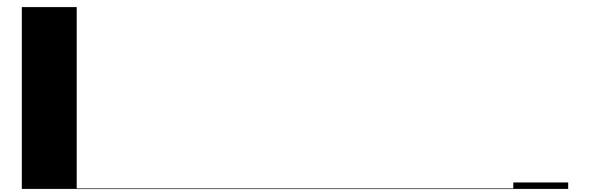

black

2

0

0.1

0.3

0.0

0.0

1.0

[figure not shown]

bus

2

0

0.1

0.3

0.0

0.0

1.0

construc

2

0

0.1

0.3

0.0

0.0

1.0

ent

2

0

0.0

0.1

0.0

0.0

1.0

exper

19

0

6.5

2.8

0.0

6.0

18.0

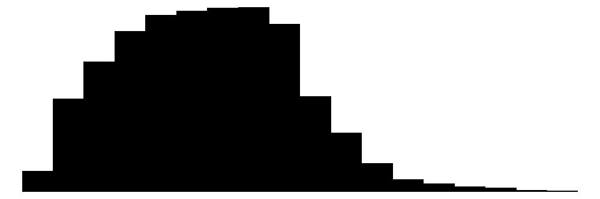

fin

2

0

0.0

0.2

0.0

0.0

1.0

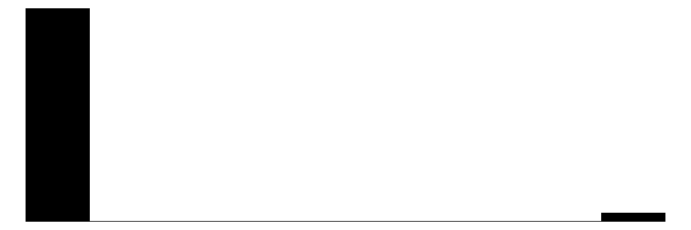

hisp

2

0

0.2

0.4

0.0

0.0

1.0

[figure not shown]

poorhlth

2

0

0.0

0.1

0.0

0.0

1.0

hours

1276

0

2191.3

566.4

120.0

2080.0

4992.0

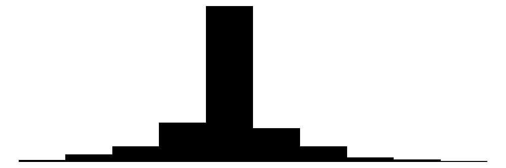

manuf

2

0

0.3

0.5

0.0

0.0

1.0

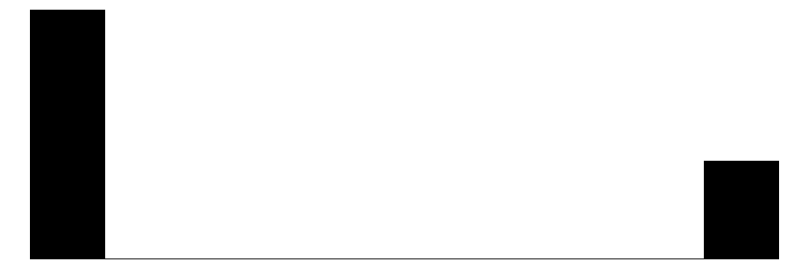

married

2

0

0.4

0.5

0.0

0.0

1.0

[figure not shown]

min

2

0

0.0

0.1

0.0

0.0

1.0

nrthcen

2

0

0.3

0.4

0.0

0.0

1.0

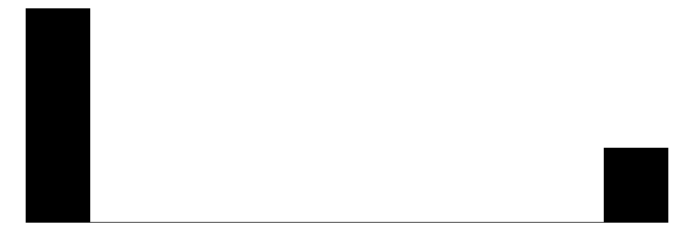

nrtheast

2

0

0.2

0.4

0.0

0.0

1.0

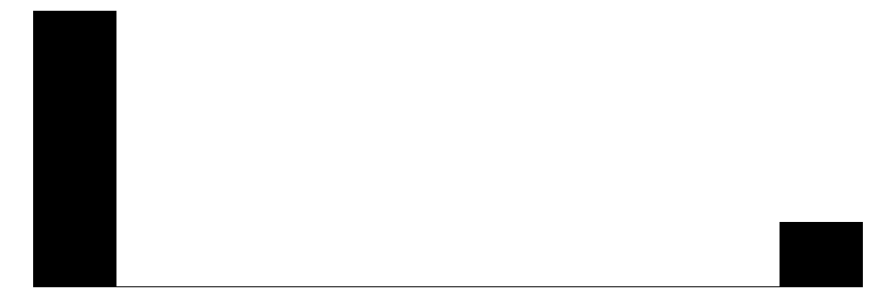

occ1

2

0

0.1

0.3

0.0

0.0

1.0

[18 more figures not shown]

```r
data("wagepan", package = "wooldridge")
datasummary_skim(wagepan)
```

Il dataset `wagepan`contiene dati sui salari di 545 lavoratori dal 1980 al 1987.

In particolare usiamo:

- $lwage$: logaritmo del salario
- $union$: variabile dummy uguale ad 1 se il lavoratore è sindacalizzato
- $exper$: anni di esperienza
- $expersq$: anni di esperienza al quadrato
- $educ$: anni di istruzione
- $black$: dummy uguale a 1 se il lavoratore è nero
- $hispanic$: dummy uguale a 1 se il lavoratore è ispanico
- $married$: dummy uguale a 1 se il lavoratore è sposato

Regressione senza effetti fissi individuali e temporali.

```r
reg_logwageunion <- feols(lwage ~ union + exper + expersq + educ + black + hisp + married, data = wagepan, vcov = "hetero")
reg_logwageunion
```

```
OLS estimation, Dep. Var.: lwage
Observations: 4,360
Standard-errors: Heteroskedasticity-robust
             Estimate Std. Error   t value   Pr(>|t|)
(Intercept) -0.034706   0.064745 -0.536039 5.9196e-01
union        0.180073   0.016242 11.086590  < 2.2e-16 ***
exper        0.089179   0.010148  8.788091  < 2.2e-16 ***
expersq     -0.002849   0.000679 -4.193440 2.8022e-05 ***
educ         0.099388   0.004596 21.626040  < 2.2e-16 ***
black       -0.143842   0.024361 -5.904497 3.8066e-09 ***
hisp         0.015698   0.019741  0.795178 4.2655e-01
married      0.107666   0.015266  7.052498 2.0350e-12 ***
---
Signif. codes:  0 '***' 0.001 '**' 0.01 '*' 0.05 '.' 0.1 ' ' 1
RMSE: 0.480302   Adj. R2: 0.185278
```

**Domande**

1. Come si interpretano i coefficienti di $educ$ e $union$ nella regressione?
- L’effetto *ceteris paribus* di essere sindacalizzato è associato a un salario medio più alto del 18% circa, a parità delle altre variabili.
- Ogni anno aggiuntivo di istruzione è associato a un salario medio più alto di circa 9.9%, a parità delle altre variabili.

### Dummy per anno (effetti temporali)

```r
feols(lwage ~ union + exper + expersq + educ + black + hisp + married + d81 + d82 + d83 + d84 + d85 + d86 + d87, data = wagepan, vcov = "hetero")
```

```
OLS estimation, Dep. Var.: lwage
Observations: 4,360
Standard-errors: Heteroskedasticity-robust
             Estimate Std. Error   t value   Pr(>|t|)
(Intercept)  0.092056   0.079457  1.158557 2.4670e-01
union        0.182461   0.016284 11.205255  < 2.2e-16 ***
exper        0.067234   0.013289  5.059563 4.3757e-07 ***
expersq     -0.002412   0.000770 -3.131406 1.7513e-03 **
educ         0.091350   0.005291 17.264168  < 2.2e-16 ***
black       -0.139234   0.024545 -5.672575 1.4980e-08 ***
hisp         0.016020   0.019719  0.812373 4.1662e-01
married      0.108253   0.015248  7.099613 1.4547e-12 ***
d81          0.058320   0.032086  1.817634 6.9189e-02 .
d82          0.062774   0.034196  1.835718 6.6468e-02 .
d83          0.062012   0.036429  1.702267 8.8777e-02 .
d84          0.090467   0.041109  2.200672 2.7812e-02 *
d85          0.109246   0.043960  2.485143 1.2987e-02 *
d86          0.141960   0.047162  3.010053 2.6270e-03 **
d87          0.173833   0.049045  3.544332 3.9775e-04 ***
---
Signif. codes:  0 '***' 0.001 '**' 0.01 '*' 0.05 '.' 0.1 ' ' 1
RMSE: 0.479507   Adj. R2: 0.186666
```

Otteniamo gli stessi risultati stimando la seguente regressione con `|year` che significa effetti fissi su $year$

```r
feols(lwage ~ union + exper + expersq + educ + black + hisp + married | year , data = wagepan, vcov = "hetero")
```

```
OLS estimation, Dep. Var.: lwage
Observations: 4,360
Fixed-effects: year: 8
Standard-errors: Heteroskedasticity-robust
         Estimate Std. Error   t value   Pr(>|t|)
union    0.182461   0.016284 11.205255  < 2.2e-16 ***
exper    0.067234   0.013289  5.059563 4.3757e-07 ***
expersq -0.002412   0.000770 -3.131406 1.7513e-03 **
educ     0.091350   0.005291 17.264168  < 2.2e-16 ***
black   -0.139234   0.024545 -5.672575 1.4980e-08 ***
hisp     0.016020   0.019719  0.812373 4.1662e-01
married  0.108253   0.015248  7.099613 1.4547e-12 ***
---
Signif. codes:  0 '***' 0.001 '**' 0.01 '*' 0.05 '.' 0.1 ' ' 1
RMSE: 0.479507     Adj. R2: 0.186666
                 Within R2: 0.12337
```

### Effetti fissi individuali

Usando `| nr` in `feols()`

```r
feols(lwage ~ union + exper + expersq + educ + black + hisp + married | nr , data = wagepan, vcov = "hetero")
```

```
OLS estimation, Dep. Var.: lwage
Observations: 4,360
Fixed-effects: nr: 545
Standard-errors: Heteroskedasticity-robust
         Estimate Std. Error  t value   Pr(>|t|)
union    0.082087   0.019496  4.21054 2.6065e-05 ***
exper    0.116847   0.009136 12.78941  < 2.2e-16 ***
expersq -0.004301   0.000599 -7.18184 8.2311e-13 ***
married  0.045303   0.018126  2.49936 1.2483e-02 *
... 3 variables were removed because of collinearity (educ, black and hisp)
---
Signif. codes:  0 '***' 0.001 '**' 0.01 '*' 0.05 '.' 0.1 ' ' 1
RMSE: 0.328397     Adj. R2: 0.565061
                 Within R2: 0.178044
```

Come vedete dall’output della regressione 3 variabili vengono rimosse ($educ$, $black$ and $hispan$).

### Deviazione dalla media (trasformazione within)

Usando `crime2` avevamo calcolato la trasformazione within per gli effetti temporali con `group_by(year)`.

Calcoliamo la traformazione within per gli effetti individuali `group_by(nr)`

```r
wagepan_demeaned <- wagepan %>%
  group_by(nr) %>%
  mutate(
    lwage_dm = lwage - mean(lwage, na.rm = TRUE),
    union_dm = union - mean(union, na.rm = TRUE),
    exper_dm = exper - mean(exper, na.rm = TRUE),
    expersq_dm = expersq - mean(expersq, na.rm = TRUE),
    educ_dm = educ - mean(educ, na.rm = TRUE),
    black_dm = black - mean(black, na.rm = TRUE),
    hisp_dm = hisp - mean(hisp, na.rm = TRUE),
    married_dm = married - mean(married, na.rm = TRUE)
  ) %>%
  ungroup()
```

```r
#L'intercetta sarà zero e la rimuovo con -1
feols(lwage_dm ~ union_dm + exper_dm + expersq_dm + educ_dm + black_dm + hisp_dm + married_dm  -1, data = wagepan_demeaned, vcov = "hetero")
```

```
OLS estimation, Dep. Var.: lwage_dm
Observations: 4,360
Standard-errors: Heteroskedasticity-robust
            Estimate Std. Error  t value   Pr(>|t|)
union_dm    0.082087   0.018235  4.50155 6.9222e-06 ***
exper_dm    0.116847   0.008546 13.67335  < 2.2e-16 ***
expersq_dm -0.004301   0.000560 -7.67822 1.9790e-14 ***
married_dm  0.045303   0.016954  2.67211 7.5657e-03 **
... 3 variables were removed because of collinearity (educ_dm, black_dm and hisp_dm)
---
Signif. codes:  0 '***' 0.001 '**' 0.01 '*' 0.05 '.' 0.1 ' ' 1
RMSE: 0.328397   Adj. R2: 0.177289
```

Il coefficiente è lo stesso ottenuto usando `|nr`. In questo caso lo standard error è leggermente diverso perchè `feols` non sa che abbiamo trasformato i dati.

### Effetti fissi individuali e temporali

```r
reg_logwageunion_fe <- feols(lwage ~ union + exper + expersq + educ + black + hisp + married | nr + year , data = wagepan, vcov = "hetero")
reg_logwageunion_fe
```

```
OLS estimation, Dep. Var.: lwage
Observations: 4,360
Fixed-effects: nr: 545,  year: 8
Standard-errors: Heteroskedasticity-robust
         Estimate Std. Error  t value   Pr(>|t|)
union    0.080002   0.019505  4.10154 4.1899e-05 ***
expersq -0.005185   0.000665 -7.80118 7.8642e-15 ***
married  0.046680   0.018117  2.57658 1.0016e-02 *
... 4 variables were removed because of collinearity (exper, educ and 2 others [full set in $collin.var])
---
Signif. codes:  0 '***' 0.001 '**' 0.01 '*' 0.05 '.' 0.1 ' ' 1
RMSE: 0.327891     Adj. R2: 0.565718
                 Within R2: 0.021568
```

In questo modello stiamo tenendo conto e quindi rimuoviamo la distorsione derivante da variabili omesse che non variano nel tempo (ma possono differire fra individui) e variabili che non variano fra individui (ma possono differire nel tempo).

Come vedete dall’output della regressione 4 variabili vengono rimosse ($exper$, $educ$, $black$ and $hispan$).

- Le variabili costanti a livello individuale sono perfettamente collineari con gli effetti fissi individuali
- con effetti fissi individuali e temporali ora viene rimossa anche $exper$

Il coefficiente associate a $union$ ora è uguale a 0.08 (il modello è log-lineare)

Stiamo controllando per tutte le caratteristiche dell’individuo che non cambiano nel tempo (ad esempio genere, etnia), ma variano tra individui; e stiamo controllando per tutto ciò che cambia nel tempo ma è comune a tutti gli individui (ad esempio inflazione, trend)

**Confronto tra i modelli:**

```r
modelsummary(list("Log Wage" = reg_logwageunion, "Log Wage" = reg_logwageunion_fe), output = "markdown", gof_omit = "AIC|BIC|RMSE|R2 Adj.")
```

|  | Log Wage | Log Wage |
| --- | --- | --- |
| (Intercept) | -0.035 |  |
|  | (0.065) |  |
| union | 0.180 | 0.080 |
|  | (0.016) | (0.020) |
| exper | 0.089 |  |
|  | (0.010) |  |
| expersq | -0.003 | -0.005 |
|  | (0.001) | (0.001) |
| educ | 0.099 |  |
|  | (0.005) |  |
| black | -0.144 |  |
|  | (0.024) |  |
| hisp | 0.016 |  |
|  | (0.020) |  |
| married | 0.108 | 0.047 |
|  | (0.015) | (0.018) |
| Num.Obs. | 4360 | 4360 |
| R2 | 0.187 | 0.621 |
| R2 Within |  | 0.022 |
| R2 Within Adj. |  | 0.021 |
| Std.Errors | Heteroskedasticity-robust | Heteroskedasticity-robust |
| FE: nr |  | X |
| FE: year |  | X |

### Wage espresso in dollari

```r
wagepan <- wagepan %>%
  mutate(wage = exp(lwage))
summary(wagepan$wage)
```

```
   Min. 1st Qu.  Median    Mean 3rd Qu.    Max.
 0.0279  3.8602  5.3182  5.9192  7.3235 57.5043
```

57.5043 $ è un possibile outlier, la trasformazione logaritmica applicata in precedenza ha aiutato (vedete istogramma in `datasummary_skim`)

```r
reg_wageunion_fe <- feols(wage ~ union + exper + expersq + educ + black + hisp + married | nr + year , data = wagepan, vcov = "hetero")
reg_wageunion_fe
```

```
OLS estimation, Dep. Var.: wage
Observations: 4,360
Fixed-effects: nr: 545,  year: 8
Standard-errors: Heteroskedasticity-robust
         Estimate Std. Error  t value   Pr(>|t|)
union    0.427204   0.115284  3.70567 0.00021383 ***
expersq -0.034536   0.003989 -8.65738  < 2.2e-16 ***
married  0.255674   0.096532  2.64858 0.00811654 **
... 4 variables were removed because of collinearity (exper, educ and 2 others [full set in $collin.var])
---
Signif. codes:  0 '***' 0.001 '**' 0.01 '*' 0.05 '.' 0.1 ' ' 1
RMSE: 1.85604     Adj. R2: 0.61505
                Within R2: 0.026392
```

### Errori standard per dati raggruppati (“clustered”)

Gli errori standard clustered per dati panel sono l’estensione logica di quelli robusti all’eteroschedasticità per dati sezionali.

Nella regressione con dati sezionali, gli errori standard robusti all’eteroschedasticità sono validi indipendentemente dal fatto che vi sia eteroschedasticità. Nella regressione con dati panel, gli errori standard clustered sono validi indipendentemente dal fatto che vi sia eteroschedasticità e/o correlazione seriale.

Il termine “clustered” deriva dal fatto che si consente correlazione in un “cluster” (o “gruppo”) di osservazioni (in una entità) ma non tra cluster.

`feols` calcola gli errori standard clustered con l’opzione `vcov = cluster`

```r
feols(wage ~ union + exper + expersq + educ + black + hisp + married | nr + year , data = wagepan, vcov = "cluster")
```

```
OLS estimation, Dep. Var.: wage
Observations: 4,360
Fixed-effects: nr: 545,  year: 8
Standard-errors: Clustered (nr)
         Estimate Std. Error  t value   Pr(>|t|)
union    0.427204   0.143829  2.97022 3.1072e-03 **
expersq -0.034536   0.005371 -6.43026 2.7908e-10 ***
married  0.255674   0.123799  2.06523 3.9374e-02 *
... 4 variables were removed because of collinearity (exper, educ and 2 others [full set in $collin.var])
---
Signif. codes:  0 '***' 0.001 '**' 0.01 '*' 0.05 '.' 0.1 ' ' 1
RMSE: 1.85604     Adj. R2: 0.61505
                Within R2: 0.026392
```